# CITS4009 Project 1

WEI YANG 21220208

Introduction

The data set analyzed can be obtained from the Kaggle platform. This dataset was collected to work on NBA games data. I used the nba stats website to create this dataset. https://www.kaggle.com/nathanlauga/nba-games

The National Basketball Association (NBA) is an American men’s professional basketball league. It is composed of 30 teams and is one of the four major professional sports leagues in the United States and Canada. It is the premier men’s professional basketball league in the world.

Data loading, overview and set up

Load libraries

```r
library(ggthemes)
library(grid)
library(ggplot2)
library(dplyr)
library(reshape2)
library(gridExtra)
```

Setting up a plotting theme

```r
cits4009_theme <- theme(plot.title = element_text(color = "darkred"),
                        axis.text.y=element_text(size=8),
                        axis.title = element_text(color='black', vjust=0.1),legend.key.size=unit(.2,"inches"))
```

Load the main data

```r
nba<- read.csv("games_details.csv")
```

Using str to analyze the data

```r
str(nba)
```

```
'data.frame':   576782 obs. of  28 variables:
 $ GAME_ID          : int  21900895 21900895 21900895 21900895 21900895 21900895 21900895 21900895 21900895 21900895 ...
 $ TEAM_ID          : int  1610612749 1610612749 1610612749 1610612749 1610612749 1610612749 1610612749 1610612749 1610612749 1610612749 ...
 $ TEAM_ABBREVIATION: chr  "MIL" "MIL" "MIL" "MIL" ...
 $ TEAM_CITY        : chr  "Milwaukee" "Milwaukee" "Milwaukee" "Milwaukee" ...
 $ PLAYER_ID        : int  202083 203507 201572 1628978 202339 1626192 201577 1628425 101107 201588 ...
 $ PLAYER_NAME      : chr  "Wesley Matthews" "Giannis Antetokounmpo" "Brook Lopez" "Donte DiVincenzo" ...
 $ START_POSITION   : chr  "F" "F" "C" "G" ...
 $ COMMENT          : chr  "" "" "" "" ...
 $ MIN              : chr  "27:08" "34:55" "26:25" "27:35" ...
 $ FGM              : num  3 17 4 1 2 2 1 1 0 4 ...
 $ FGA              : num  11 28 11 5 8 5 5 2 1 11 ...
 $ FG_PCT           : num  0.273 0.607 0.364 0.2 0.25 0.4 0.2 0.5 0 0.364 ...
 $ FG3M             : num  2 1 1 0 0 1 0 1 0 1 ...
 $ FG3A             : num  7 4 5 3 1 4 0 2 1 4 ...
 $ FG3_PCT          : num  0.286 0.25 0.2 0 0 0.25 0 0.5 0 0.25 ...
 $ FTM              : num  0 6 7 0 0 1 0 0 0 2 ...
 $ FTA              : num  0 7 9 0 0 2 0 0 0 3 ...
 $ FT_PCT           : num  0 0.857 0.778 0 0 0.5 0 0 0 0.667 ...
 $ OREB             : num  4 2 2 1 1 2 1 0 0 2 ...
 $ DREB             : num  4 18 5 6 0 3 2 3 2 3 ...
 $ REB              : num  8 20 7 7 1 5 3 3 2 5 ...
 $ AST              : num  2 6 0 5 2 1 0 0 2 2 ...
 $ STL              : num  2 1 0 0 1 0 0 0 1 2 ...
 $ BLK              : num  0 0 3 1 0 0 1 0 1 0 ...
 $ TO               : num  0 3 0 2 3 1 2 1 1 3 ...
 $ PF               : num  0 2 2 0 2 2 1 0 1 1 ...
 $ PTS              : num  8 41 16 2 4 6 2 3 0 11 ...
 $ PLUS_MINUS       : num  11 22 16 14 6 0 -12 -8 -11 2 ...
```

Using summary to analyze the data

```r
summary(nba)
```

```
    GAME_ID            TEAM_ID          TEAM_ABBREVIATION   TEAM_CITY
 Min.   :10300001   Min.   :1.611e+09   Length:576782      Length:576782
 1st Qu.:20600629   1st Qu.:1.611e+09   Class :character   Class :character
 Median :21100461   Median :1.611e+09   Mode  :character   Mode  :character
 Mean   :21535815   Mean   :1.611e+09
 3rd Qu.:21600196   3rd Qu.:1.611e+09
 Max.   :41800406   Max.   :1.611e+09

   PLAYER_ID         PLAYER_NAME        START_POSITION       COMMENT
 Min.   :1.500e+01   Length:576782      Length:576782      Length:576782
 1st Qu.:2.366e+03   Class :character   Class :character   Class :character
 Median :2.008e+05   Mode  :character   Mode  :character   Mode  :character
 Mean   :2.794e+05
 3rd Qu.:2.027e+05
 Max.   :1.963e+09

     MIN                 FGM             FGA            FG_PCT
 Length:576782      Min.   : 0.00   Min.   : 0.00   Min.   :0.00
 Class :character   1st Qu.: 1.00   1st Qu.: 3.00   1st Qu.:0.25
 Mode  :character   Median : 3.00   Median : 7.00   Median :0.43
                    Mean   : 3.56   Mean   : 7.86   Mean   :0.42
                    3rd Qu.: 5.00   3rd Qu.:11.00   3rd Qu.:0.56
                    Max.   :28.00   Max.   :50.00   Max.   :1.00
                    NA's   :92261   NA's   :92261   NA's   :92261
      FG3M            FG3A          FG3_PCT           FTM             FTA
 Min.   : 0.00   Min.   : 0.00   Min.   :0.00    Min.   : 0.00   Min.   : 0.00
 1st Qu.: 0.00   1st Qu.: 0.00   1st Qu.:0.00    1st Qu.: 0.00   1st Qu.: 0.00
 Median : 0.00   Median : 1.00   Median :0.00    Median : 1.00   Median : 2.00
 Mean   : 0.72   Mean   : 2.02   Mean   :0.19    Mean   : 1.75   Mean   : 2.32
 3rd Qu.: 1.00   3rd Qu.: 3.00   3rd Qu.:0.33    3rd Qu.: 3.00   3rd Qu.: 4.00
 Max.   :14.00   Max.   :24.00   Max.   :1.00    Max.   :26.00   Max.   :39.00
 NA's   :92261   NA's   :92261   NA's   :92261   NA's   :92261   NA's   :92261
     FT_PCT           OREB            DREB            REB             AST
 Min.   :0.00    Min.   : 0.00   Min.   : 0.00   Min.   : 0.00   Min.   : 0.00
 1st Qu.:0.00    1st Qu.: 0.00   1st Qu.: 1.00   1st Qu.: 1.00   1st Qu.: 0.00
 Median :0.50    Median : 1.00   Median : 2.00   Median : 3.00   Median : 1.00
 Mean   :0.44    Mean   : 1.04   Mean   : 3.01   Mean   : 4.05   Mean   : 2.08
 3rd Qu.:0.91    3rd Qu.: 2.00   3rd Qu.: 4.00   3rd Qu.: 6.00   3rd Qu.: 3.00
 Max.   :1.00    Max.   :18.00   Max.   :25.00   Max.   :31.00   Max.   :25.00
 NA's   :92261   NA's   :92261   NA's   :92261   NA's   :92261   NA's   :92261
      STL             BLK              TO              PF             PTS
 Min.   : 0.00   Min.   : 0.00   Min.   : 0.00   Min.   : 0.00   Min.   : 0.0
 1st Qu.: 0.00   1st Qu.: 0.00   1st Qu.: 0.00   1st Qu.: 1.00   1st Qu.: 3.0
 Median : 0.00   Median : 0.00   Median : 1.00   Median : 2.00   Median : 8.0
 Mean   : 0.72   Mean   : 0.46   Mean   : 1.33   Mean   : 2.02   Mean   : 9.6
 3rd Qu.: 1.00   3rd Qu.: 1.00   3rd Qu.: 2.00   3rd Qu.: 3.00   3rd Qu.:14.0
 Max.   :10.00   Max.   :12.00   Max.   :12.00   Max.   :15.00   Max.   :81.0
 NA's   :92261   NA's   :92261   NA's   :92261   NA's   :92261   NA's   :92261
   PLUS_MINUS
 Min.   :-57
 1st Qu.: -7
 Median :  0
 Mean   :  0
 3rd Qu.:  6
 Max.   : 57
 NA's   :115922
```

Viewing the first six observations

```r
head(nba)
```

|  | GAME_ID | TEAM_ID | TEAM_ABBREVIATION | TEAM_CITY | PLAYER_ID | PLAYER_NAME | START_POSITION | COMMENT | MIN | FGM | FGA | FG_PCT | FG3M | FG3A | FG3_PCT | FTM | FTA | FT_PCT | OREB | DREB | REB | AST | STL | BLK | TO | PF | PTS | PLUS_MINUS |
| --- | --- | --- | --- | --- | --- | --- | --- | --- | --- | --- | --- | --- | --- | --- | --- | --- | --- | --- | --- | --- | --- | --- | --- | --- | --- | --- | --- | --- |
| 1 | 21900895 | 1610612749 | MIL | Milwaukee | 202083 | Wesley Matthews | F |  | 27:08 | 3 | 11 | 0.273 | 2 | 7 | 0.286 | 0 | 0 | 0.000 | 4 | 4 | 8 | 2 | 2 | 0 | 0 | 0 | 8 | 11 |
| 2 | 21900895 | 1610612749 | MIL | Milwaukee | 203507 | Giannis Antetokounmpo | F |  | 34:55 | 17 | 28 | 0.607 | 1 | 4 | 0.250 | 6 | 7 | 0.857 | 2 | 18 | 20 | 6 | 1 | 0 | 3 | 2 | 41 | 22 |
| 3 | 21900895 | 1610612749 | MIL | Milwaukee | 201572 | Brook Lopez | C |  | 26:25 | 4 | 11 | 0.364 | 1 | 5 | 0.200 | 7 | 9 | 0.778 | 2 | 5 | 7 | 0 | 0 | 3 | 0 | 2 | 16 | 16 |
| 4 | 21900895 | 1610612749 | MIL | Milwaukee | 1628978 | Donte DiVincenzo | G |  | 27:35 | 1 | 5 | 0.200 | 0 | 3 | 0.000 | 0 | 0 | 0.000 | 1 | 6 | 7 | 5 | 0 | 1 | 2 | 0 | 2 | 14 |
| 5 | 21900895 | 1610612749 | MIL | Milwaukee | 202339 | Eric Bledsoe | G |  | 22:17 | 2 | 8 | 0.250 | 0 | 1 | 0.000 | 0 | 0 | 0.000 | 1 | 0 | 1 | 2 | 1 | 0 | 3 | 2 | 4 | 6 |
| 6 | 21900895 | 1610612749 | MIL | Milwaukee | 1626192 | Pat Connaughton |  |  | 24:52 | 2 | 5 | 0.400 | 1 | 4 | 0.250 | 1 | 2 | 0.500 | 2 | 3 | 5 | 1 | 0 | 0 | 1 | 2 | 6 | 0 |

Show range of game_ID

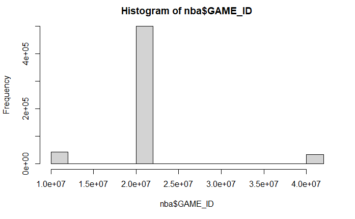

```r
hist(nba$GAME_ID)
```

It can been seen that there are 3 types of games which are preseason,regular season and playoff. We only focus on regular season games.

Remove gameID start from 1 which are preseason

```r
nba<- nba[which(nba$GAME_ID>"20000000"&nba$GAME_ID<"40000000"),]
```

Add column of years of games

```r
year<-function(a){#write a function to generate year from GAMEID
    a1<-"20"
    a2<-substring(a,2,3)
    paste(a1,a2,sep="")
}
nba<-mutate(nba,year=year(GAME_ID))
nba<-nba[which(nba$year>"2006"),]
```

Convert mins to a int inorder to do calculation later on

```r
Min<-function(a){#write a function to transform a string of time into a num
b<- strsplit(a,split = ":")
b<-unlist(b)
min<- as.numeric(b[1])
sec <- as.numeric(b[2])
result<- round((min+sec/60),1)
}
i=1
while(i<=length(nba)){
  nba$MIN[i]<- Min(nba$MIN[i])
  i=i+1
}
```

Analyze the number of NA each variables

```r
apply(is.na(nba), 2, sum)
```

```
          GAME_ID           TEAM_ID TEAM_ABBREVIATION         TEAM_CITY
                0                 0                 0                 0
        PLAYER_ID       PLAYER_NAME    START_POSITION           COMMENT
                0                 0                 0                 0
              MIN               FGM               FGA            FG_PCT
                7             63780             63780             63780
             FG3M              FG3A           FG3_PCT               FTM
            63780             63780             63780             63780
              FTA            FT_PCT              OREB              DREB
            63780             63780             63780             63780
              REB               AST               STL               BLK
            63780             63780             63780             63780
               TO                PF               PTS        PLUS_MINUS
            63780             63780             63780             63780
             year
                0
```

```r
nba <- na.omit(nba)
```

calculate TS

```r
nba<-mutate(nba,TS=round(PTS/(2*(FGA+0.44*FTA)),3))
nba$TS <- ifelse(is.na(nba$TS),0,nba$TS)
```

Based on the above observations, we’ll convert some columns to a more appropriate format and add new ones that might be useful in further analysis.

```r
nba[which(nba$START_POSITION !=""),7]<-c("SF","PF","C","SG","PG")#transform 3 position into 6
nba[which(nba$START_POSITION ==""),7]<-"SUB"
nba <- within(nba, {
          START_POSITION <- as.factor(START_POSITION)
})
```

Anylise the trend of scoring

Generate data for analysing

```r
games<-aggregate(nba[,c(10,11,13,14,16,17,19:27)],by=list(gameID=nba$GAME_ID),FUN=sum)
games<-mutate(games,year=year(gameID))
team<-aggregate(games[,2:16],by=list(year=games$year),FUN=mean)#transform data
```

First let us have a look at the distribution of score in a games

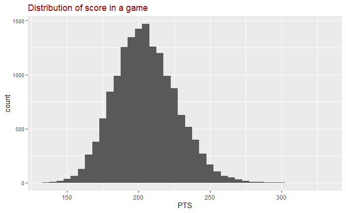

```r
ggplot(data = games, mapping = aes(x =PTS ))+ labs(  title = "Distribution of score in a game")+geom_histogram(binwidth=5)+cits4009_theme #plot the histogram of PTS.
```

plot the trend of average points in a game

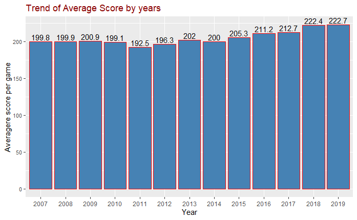

```r
ggplot(data=team, mapping=aes(x=year, y=PTS)) +geom_bar(stat='identity',colour = "red", fill = 'steelblue')+labs(  title = "Trend of Average Score by years",x = "Year",y = "Averagere score per game")+ geom_text(mapping = aes(label = round(PTS,1)),vjust=-0.25)+cits4009_theme
```

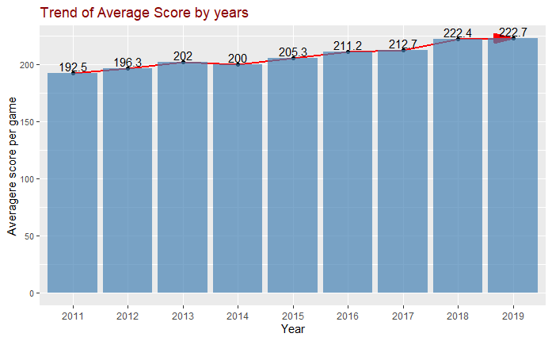

```r
team<-team[which(team$year>"2010"),]
myarrow=arrow(angle = 15, type = "closed")
ggplot(data=team, mapping=aes(x=year, y=PTS, group=1))+  geom_line(colour = "red",arrow=myarrow,size=1,linetype=1)+geom_point() +geom_bar( alpha=0.7,stat='identity', fill = 'steelblue')+labs(  title = "Trend of Average Score by years",x = "Year",y = "Averagere score per game")+geom_text(mapping = aes(label = round(PTS,1)),vjust=-0.25)+cits4009_theme
```

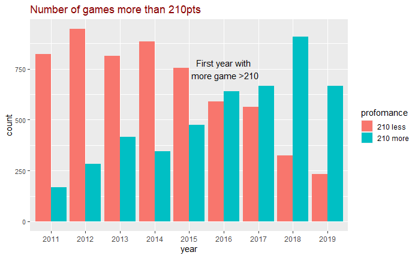

```r
more<-function(a){ #function turns  numerical into catagorical
   ifelse(a>=210,"210 more","210 less")
}
games<-mutate(games,profomance=more(games$PTS))
games<- games[which(games$year>"2010"),]
ggplot(games) +geom_bar(aes(x=year, fill=profomance),position="dodge")+labs(title = "Number of games more than 210pts")+cits4009_theme+annotate("text", x = "2016", y = 750,label = "First year with\n more game >210")
```

Firstly, let us analyze Field goal percentage wihich inculding Total Field goal percentage,3-points Field goal percentage and penalty Field goal percentage.

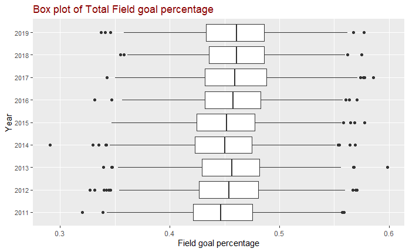

```r
games<-mutate(games,FG_PCT=games$FGM/FGA)
games<-mutate(games,FG3_PCT=FG3M/FG3A)
games<-mutate(games,FT_PCT=FTM/FTA)

ggplot(data = games, mapping = aes(x = year, y = FG_PCT)) +geom_boxplot()+labs(  title = "Box plot of Total Field goal percentage ",x = "Year",y = "Field goal percentage")+cits4009_theme +coord_flip()
```

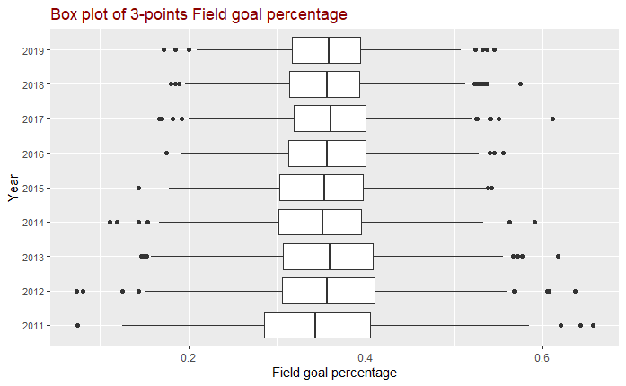

```r
ggplot(data = games, mapping = aes(x = year, y = FG3_PCT)) +geom_boxplot()+labs(  title = "Box plot of 3-points Field goal percentage ",x = "Year",y = "Field goal percentage")+cits4009_theme+coord_flip()
```

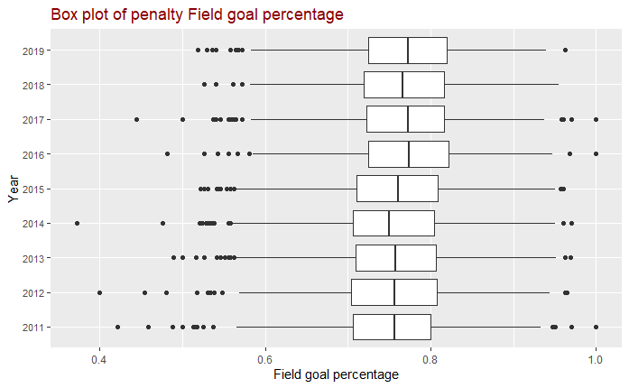

```r
ggplot(data = games, mapping = aes(x = year, y = FT_PCT)) +geom_boxplot()+labs(  title = "Box plot of penalty Field goal percentage ",x = "Year",y = "Field goal percentage")+cits4009_theme+coord_flip()
```

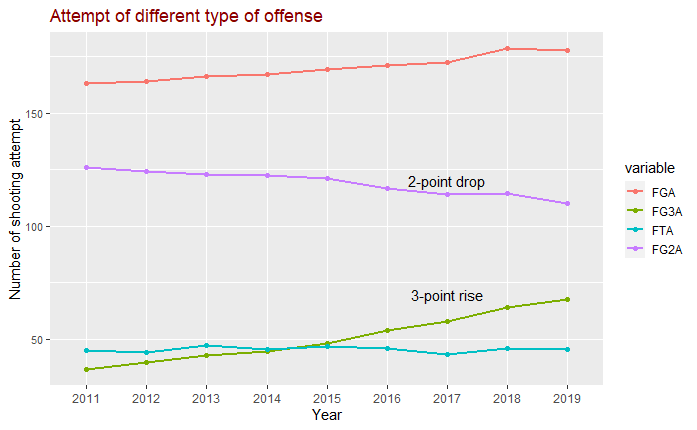

```r
games<-mutate(games,FG2A=games$FGA-games$FG3A)
team1<-aggregate(games[,c(2:16,22)],by=list(year=games$year),FUN=mean)
team1<-reshape2::melt(data=team1,id.vars=c('year'),measure.vars = c('FGA','FG3A','FTA','FG2A'),variable.names= 'FG',value.name='FGA')

ggplot(data=team1, mapping=aes(x=year, y=FGA,colour=variable, group=variable))+  geom_line(size=1,linetype=1)+geom_point() +labs(  title = "Attempt of different type of offense",x = "Year",y = "Number of shooting attempt")+cits4009_theme+annotate("text", x = "2017", y = 120,label = "2-point drop") +annotate("text", x = "2017", y = 70,label = "3-point rise")
```

According to the line chart, the total shooting attempts increase steadily which contribute to the increase of total score. Besides, a more interesting phenomenon has been found. The composition of shots changes significantly,with more and more 3 point shoot was made. As we know from the previous analysis, the total percentage of field goal keep unchange and more 3 point shots were made. It also contributes to the increase of score. In order to show this more clearly, a new index is calculate which is called True Percentage(TS).In basketball, true shooting percentage is an advanced statistic that measures a player’s efficiency at shooting the ball. It is intended to more accurately calculate a player’s shooting than field goal percentage, free throw percentage, and three-point field goal percentage taken individually.

Let us present the relationship between 3 point shots and TS.

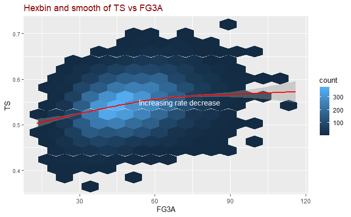

```r
games1<-mutate(games,TS=round(PTS/(2*(FGA+0.44*FTA)),3))

ggplot(data = games1,mapping = aes(x = FG3A, y = TS)) +geom_hex(bins=15)+ geom_smooth(colour='red')+labs(  title = "Hexbin and smooth of TS vs FG3A")+cits4009_theme+annotate("text", x = 70, y = 0.55,colour='white',
label = "Increasing rate decrease")
```

It is obvious that the more 3 point shots a team makes, the higher TS it is likely to get.

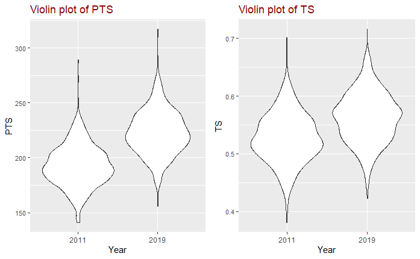

```r
games<-mutate(games,TS=round(PTS/(2*(FGA+0.44*FTA)),3))
p1<-ggplot(data = games[which(games$year==2011|games$year==2019),], mapping = aes(x = year, y = PTS)) +geom_violin()+labs(  title = "Violin plot of PTS ",x = "Year",y = "PTS")+cits4009_theme

p2<-ggplot(data = games[which(games$year==2011|games$year==2019),], mapping = aes(x = year, y = TS)) +geom_violin()+labs(  title = "Violin plot of TS ",x = "Year",y = "TS")+cits4009_theme
grid.arrange(p1, p2, ncol=2)
```

Conclusion

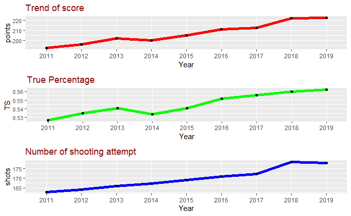

```r
team2<-mutate(team,TS=round(PTS/(2*(FGA+0.44*FTA)),3))

p1<-ggplot(data=team2, mapping=aes(x=year, y=PTS, group=1))+  geom_line(colour = "red",size=2,linetype=1)+geom_point() +labs(  title = "Trend of score",x = "Year",y = "points")+cits4009_theme

p2<-ggplot(data=team2, mapping=aes(x=year, y=TS, group=1))+  geom_line(colour = "green",size=2,linetype=1)+geom_point() +labs(  title = "True Percentage ",x = "Year",y = "TS")+cits4009_theme

p3<-ggplot(data=team2, mapping=aes(x=year, y=FGA, group=1))+  geom_line(colour = "blue",size=2,linetype=1)+geom_point() +labs(  title = "Number of shooting attempt",x = "Year",y = "shots")+cits4009_theme
grid.arrange(p1, p2,p3, ncol=1)
```

In conclusion, the score of a game show an upward trend during the last 10 years. It is mainly due to the faster pace of games and the higher Ture percentage of shooting and the higher TS is as a result of more three-point attempts in modern basketball.

Analyze the impact of basketball trends on teams

After finishing first step of analysis, a question has generated. Does every team increase their 3 point shots and the pace of the games, or it is only leaded by particular teams? Which team or teams lead the change?

First we need to transfrom the data

```r
nba<-nba[which(nba$year>"2010"),]
teams<-aggregate(nba[,c(10,11,13,14,16,17,19:28)],by=list(year=nba$year,team=nba$TEAM_ABBREVIATION,gameID=nba$GAME_ID),FUN=sum)
teams<-aggregate(teams[,4:19],by=list(year=teams$year,team=teams$team),FUN=mean)
teams<-mutate(teams,TS=round(PTS/(2*(FGA+0.44*FTA)),3))
```

Plot the trend of 3-point shooting for each team

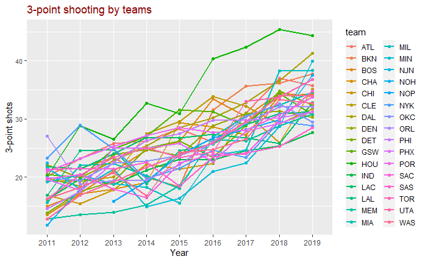

```r
ggplot(data=teams, mapping=aes(x=year, y=FG3A,colour=team, group=team))+  geom_line(size=1)+geom_point() +labs( title = "3-point shooting by teams",x = "Year",y = "3-point shots")+cits4009_theme
```

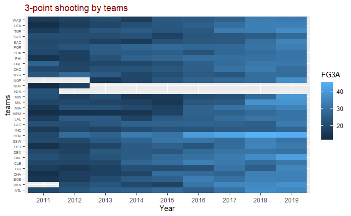

```r
ggplot(data=teams,mapping=aes(x=year, fill=FG3A,y=team, group=team))+  geom_tile() +labs( title = "3-point shooting by teams",x = "Year",y = "teams")+theme(plot.title = element_text(color = "darkred"),axis.text.y=element_text(size=5) )
```

It can be seen from the chart, in 2011, all teams but one shoot no more than 25 3- point ball. In 2019, all teams shoot more than 27 and the most can reach nearly 45 per game.

However,there are too many lines on the same graph which make the chart unclear to read. So top 3 teams and the last one in 3 point shooting in 2019 are selected.``` They are HOU,DAL,MIN and IND.

```r
a<-teams[which(teams$year==2019),]
a[order(-a$FG3A),]
```

|  | year | team | FGM | FGA | FG3M | FG3A | FTM | FTA | OREB | DREB | REB | AST | STL | BLK | TO | PF | PTS | PLUS_MINUS | TS |
| --- | --- | --- | --- | --- | --- | --- | --- | --- | --- | --- | --- | --- | --- | --- | --- | --- | --- | --- | --- |
| 98 | 2019 | HOU | 41.40678 | 90.98305 | 15.593220 | 44.38983 | 20.40678 | 25.93220 | 10.355932 | 35.01695 | 45.37288 | 21.42373 | 8.406780 | 5.152542 | 14.03390 | 21.50847 | 118.8136 | 23.728814 | 0.580 |
| 62 | 2019 | DAL | 41.55738 | 89.80328 | 15.262295 | 41.27869 | 18.18033 | 23.40984 | 10.737705 | 36.36066 | 47.09836 | 24.40984 | 6.049180 | 4.868852 | 12.11475 | 19.31148 | 116.5574 | 30.737705 | 0.582 |
| 161 | 2019 | MIN | 40.15254 | 91.72881 | 13.355932 | 39.96610 | 19.18644 | 25.50847 | 10.627119 | 34.50847 | 45.13559 | 23.66102 | 8.627119 | 5.932203 | 14.67797 | 21.50847 | 112.8475 | -21.525424 | 0.548 |
| 152 | 2019 | MIL | 43.83333 | 91.23333 | 13.883333 | 38.40000 | 18.03333 | 24.31667 | 9.566667 | 42.56667 | 52.13333 | 26.20000 | 7.416667 | 6.216667 | 14.38333 | 18.98333 | 119.5833 | 63.666667 | 0.587 |
| 17 | 2019 | BKN | 40.08475 | 90.22034 | 12.949153 | 37.72881 | 17.52542 | 23.64407 | 10.694915 | 37.59322 | 48.28814 | 24.15254 | 6.576271 | 4.593220 | 14.69492 | 20.59322 | 110.6441 | -2.966102 | 0.550 |
| 171 | 2019 | NOP | 42.41667 | 91.78333 | 14.000000 | 37.51667 | 16.98333 | 23.13333 | 11.116667 | 35.65000 | 46.76667 | 26.78333 | 7.533333 | 5.166667 | 15.56667 | 20.93333 | 115.8167 | -5.250000 | 0.568 |
| 252 | 2019 | TOR | 40.68333 | 88.83333 | 13.683333 | 36.83333 | 17.75000 | 22.28333 | 9.833333 | 35.46667 | 45.30000 | 25.50000 | 8.783333 | 5.050000 | 13.70000 | 21.51667 | 112.8000 | 31.833333 | 0.572 |
| 9 | 2019 | ATL | 40.51613 | 90.08065 | 11.870968 | 35.74194 | 18.59677 | 23.50000 | 9.645161 | 33.37097 | 43.01613 | 23.83871 | 7.935484 | 5.145161 | 15.72581 | 23.01613 | 111.5000 | -38.064516 | 0.555 |
| 44 | 2019 | CHI | 39.38333 | 88.35000 | 12.316667 | 35.16667 | 15.76667 | 20.81667 | 10.383333 | 31.56667 | 41.95000 | 23.15000 | 10.016667 | 4.000000 | 14.70000 | 21.66667 | 106.8500 | -15.916667 | 0.548 |
| 234 | 2019 | SAC | 40.13333 | 87.98333 | 12.583333 | 34.85000 | 15.45000 | 20.23333 | 9.716667 | 32.68333 | 42.40000 | 23.28333 | 7.566667 | 4.250000 | 13.66667 | 21.83333 | 108.3000 | -10.000000 | 0.559 |

[output cut: 20 more lines]

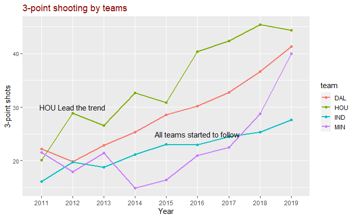

```r
teams1<-teams[which(teams$team=="HOU"|teams$team=="DAL"|teams$team=="MIN"|teams$team=="IND"),]#transform data
ggplot(data=teams1, mapping=aes(x=year, y=FG3A,colour=team, group=team))+  geom_line(size=1)+geom_point() +labs( title = "3-point shooting by teams",x = "Year",y = "3-point shots")+cits4009_theme+annotate("text", x = "2012", y = 30,
label = "HOU Lead the trend") +annotate("text", x = "2016", y = 25,
label = "All teams started to follow")
```

HOU shoot only 20 3-point per game in 2011 and then increase dramatically year by year. It reach the peak in 2018 wich 45 per game. There was a big jump between 2011-2012 for HOU with others still at a low level.

Then I want to see Scoring characteristics of HOU

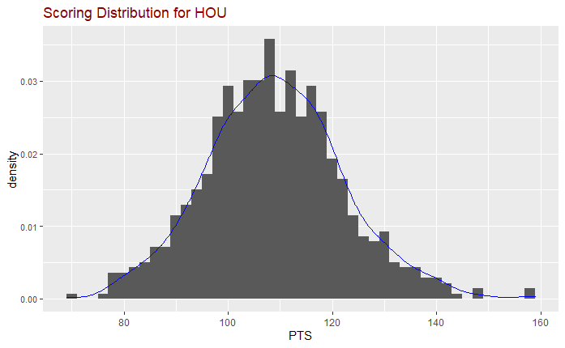

```r
HOU<-aggregate(nba[,c(10,11,13,14,16,17,19:28)],by=list(year=nba$year,team=nba$TEAM_ABBREVIATION,gameID=nba$GAME_ID),FUN=sum)
HOU<-HOU[HOU$team=="HOU",]
HOU_mean<-aggregate(HOU[,4:19],by=list(year=HOU$year,team=HOU$team),FUN=mean)
HOU_mean<-mutate(HOU_mean,FG2M=HOU_mean$FGM-HOU_mean$FG3M)
HOU_mean<-mutate(HOU_mean,FG2P=FG2M*2)
HOU_mean<-mutate(HOU_mean,FG3P=FG3M*3)
HOU_mean<-mutate(HOU_mean,FTP=FTM)
HOU_mean<-mutate(HOU_mean,Total=FTP+FG3P+FG2P)
HOU_long<-reshape2::melt(data=HOU_mean,id.vars=c('year','team'),measure.vars = c('FG3P','FTP','FG2P'),variable.names= 'FG',value.name='FGA')#transform data
ggplot(data = HOU, mapping = aes(x = PTS,  y=..density..)) +
  geom_histogram(binwidth=2) +
  geom_density(colour = "blue", alpha=0.5 )+labs(  title = "Scoring Distribution for HOU ")+cits4009_theme
```

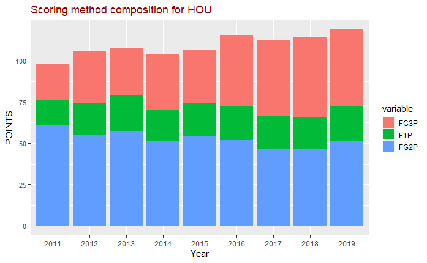

```r
ggplot( data = HOU_long,aes(x = year, y = FGA, fill = variable))+geom_bar(stat = "identity")+labs(  title = "Scoring method composition for HOU ",x = "Year",y = "POINTS")+cits4009_theme
```

Then I will analysis the relation between 3-point shooting vs total point for HOU

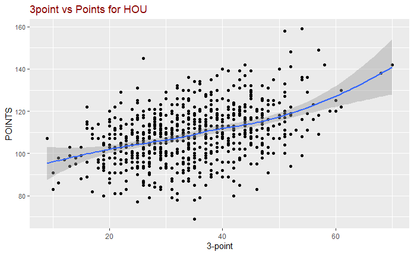

```r
ggplot(data = HOU,mapping = aes(x = FG3A, y = PTS)) +geom_point() +
geom_smooth()+labs(  title = "3point vs Points for HOU ",x = "3-point",y = "POINTS")+cits4009_theme
```

It is generally that the more 3 point HOU Shoots, the higher score they are likely to get.

Analyze the impact of basketball trends on players

After analyzing the impact of basketball trends on teams,I also want to see the the impact of basketball trends on players. I will focus on the impact on players on different positions. As can be seen from the previous analysis the game become faster and more 3 point shots was made.

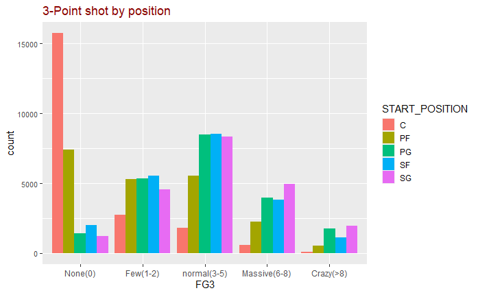

```r
nba$FG3<- cut(nba$FG3A,breaks = c(-Inf,0,2,5,8,Inf),right =T,labels=c("None(0)","Few(1-2)","normal(3-5)","Massive(6-8)","Crazy(>8)"))
nba1<-nba[which(nba$START_POSITION!="SUB"),]

ggplot(nba1) +geom_bar(aes(x=FG3, fill=START_POSITION),position="dodge")+labs(title = "3-Point shot by position")+cits4009_theme
```

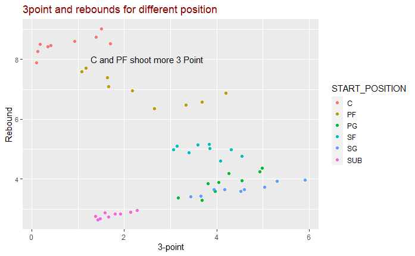

```r
position<-aggregate(nba[,c(14,21,27,30)],by=list(START_POSITION=nba$START_POSITION,year=nba$year),FUN=mean)#transform data
p <- ggplot(data = position,  mapping = aes(
  x = FG3A, y = REB,
  color = START_POSITION))
p + geom_jitter(width=0.05, height=0.05)+labs(  title = "3point and rebounds for different position",x = "3-point",y = "Rebound")+cits4009_theme+annotate("text", x = 2.5, y = 8,label = "C and PF shoot more 3 Point")
```

It is expected that guard with shorter height and better shooting skills may perform better than before. On the other hand Center with low speed and lack of shooting skill will be less dominant on the court.Let’s see if this is the case.

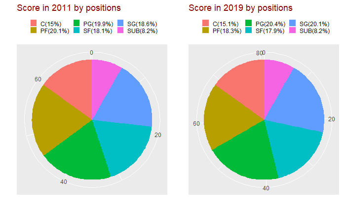

```r
position<-aggregate(nba[,c(14,21,27,30)],by=list(START_POSITION=nba$START_POSITION,year=nba$year),FUN=mean)

ps11<- position[which(position$year==2011),]#transform data
ps19<- position[which(position$year==2019),]
myLabel = as.vector(ps11$START_POSITION)
myLabel = paste(myLabel, "(", round(ps11$PTS / sum(ps11$PTS) * 100, 1), "%)", sep = "")
myLabel19 = as.vector(ps19$START_POSITION)
myLabel19 = paste(myLabel19, "(", round(ps19$PTS / sum(ps19$PTS) * 100, 1),"%)", sep = "")

p1<-ggplot(ps11, aes(x = "", y = PTS, fill = START_POSITION)) + geom_bar(stat = "identity") + coord_polar(theta = "y")+ labs(x = "", y = "", title = "Score in 2011 by positions")+ theme(axis.ticks = element_blank()) + theme(legend.title = element_blank(), legend.position = "top") + scale_fill_discrete(breaks = ps11$START_POSITION, labels = myLabel) +theme(plot.title = element_text(color = "darkred"),
                        axis.text.y=element_text(size=8),
                        axis.title = element_text(color='black', vjust=0.1),legend.key.size=unit(.15,"inches"))

p2<-ggplot(ps19, aes(x = "", y = PTS, fill = START_POSITION)) + geom_bar(stat = "identity") + coord_polar(theta = "y")+ labs(x = "", y = "", title = "Score in 2019 by positions")+ theme(axis.ticks = element_blank()) + theme(legend.title = element_blank(), legend.position = "top") + scale_fill_discrete(breaks = ps19$START_POSITION, labels = myLabel19) +theme(plot.title = element_text(color = "darkred"),
                        axis.text.y=element_text(size=8),
                        axis.title = element_text(color='black', vjust=0.1),legend.key.size=unit(.15,"inches"))
grid.arrange(p1, p2, nrow=1)
```

It can be seen that the position of guard(both pg and sg) shows a increase in score from 19.9% and 18.6% to 20.4% and 20.1% respectively as expected. However, center keep uneven which is not as expected. The decrease of scoring was seen in position of SF and PF.